# NNLS for proportional localisation

Tom Smith

Cambridge Centre for Proteomics

19 April, 2022

Abstract

Here, we use NNLS for proportional localisation assignment

```r
library(pRoloc)
library(pRolocExt)
library(tidyverse)
library(camprotR)
library(glmnet)
library(pbapply)
```

Read in the data and subset to gene-level SIRV-corrected datasets

```r
gene_quant <- readRDS('../2_data_processing/out/all_datasets.rds')$gene$corrected

getMarkers(gene_quant)
```

```
organelleMarkers
      Cytosol      Membrane Mitochondrion       Nucleus       unknown
           20            14            13            14         14592
```

Define a function to estimate proportions using the average profiles for markers

```r
get_proportions <- function(obj,
                            iterations,
                            sample=TRUE,
                            sample_proportion=1,
                            n=NULL,
                            cores=4,
                            feature_col='markers'){

  complete_data<- obj %>% filterNA()

  ########
  # get average profiles for all localisations,
  # with boostrapping proceedure to sample the markers

  complete_data <- complete_data[fData(complete_data)[[feature_col]]!='unknown',]
  complete_rows <- rownames(complete_data)

  sampled_data <- 1:iterations %>% pblapply(function(x){
      if(sample){
        sampled_row <- sample(complete_rows, length(complete_rows)*sample_proportion, replace=TRUE)
        sampled_e <- exprs(complete_data)[sampled_row,]
        sampled_f  <- fData(complete_data)[sampled_row,]
        rownames(sampled_e) <- 1:nrow(sampled_e)
        rownames(sampled_f) <- 1:nrow(sampled_f)

        MSnSet(sampled_e, sampled_f)

      } else{complete_data}
    }, cl=cores)

  names(sampled_data) <- 1:iterations

  sampled_data <- sampled_data[sapply(sampled_data, FUN=function(x){
    length(getMarkerClasses(x, feature_col))==length(getMarkerClasses(complete_data, feature_col))})]

  ave_profiles <- sampled_data %>% pblapply(function(x){
    mrkConsProfiles(x, feature_col)
  }, cl=cores)

  ########

  # Remove RNAs encoded in the mitochondiral genome. These are all Mt markers
  #obj <- obj[fData(obj)$chromosome_name != 'MT', ]

  if(missing(n)){
    n <- nrow(obj)
  }

  rows <- pblapply(1:n, function(row_id){

    iteration_results <- lapply(ave_profiles, function(ave_profile){

      indep_var <- t(ave_profile)

      fit <- glmnet(indep_var,
                    exprs(obj)[row_id,],
                    family='gaussian',
                    lower.limits=0,
                    lambda=0,
                    alpha=0)

      coefs <- coefficients(fit)[,1]

      coefs[2:length(coefs)] <- coefs[2:length(coefs)]/sum(coefs[2:length(coefs)])

      return(c(coefs, 'var_explained'=fit$dev.ratio))
      }) %>% do.call(what='rbind')

    iteration_results_summarised <- lapply(2:nrow(iteration_results), function(n){
        mean_values <- apply(iteration_results[1:n,], MARGIN=2, mean)
        sd <- apply(iteration_results[1:n,], MARGIN=2, sd)
        names(mean_values) <- paste0('mean_', names(mean_values))
        names(sd) <- paste0('sd_', names(sd))

        return(c(sd, mean_values, 'iterations'=n))
      }) %>% do.call(what='rbind') %>%
      apply(MARGIN=2, FUN=mean)

    return(iteration_results_summarised)
  }, cl=cores)


  rows <- rows %>%
    do.call(what='rbind') %>%
    data.frame()

  rows$markers=fData(obj)[[feature_col]][1:n]
  rows$id=rownames(fData(obj))[1:n]

  return(rows)
}
```

Estimate proportions

```r
start_time <- Sys.time()

iterations <- 100
sampling_rate <- 0.8

proportions_per_rep <-
  unique(pData(gene_quant)$replicate) %>%
  lapply(function(rep){
    print(rep)

    proportions <- get_proportions(
      obj=gene_quant[,pData(gene_quant)$replicate==rep],
      iterations=iterations,
      sample_proportion=sampling_rate,
      cores=4)

    proportions <- proportions %>% mutate(replicate=rep)

    return(proportions)
  })


end_time <- Sys.time()

print(end_time-start_time)

proportions_per_rep %>% saveRDS('./out/proportions_per_rep.rds')
```

Convert to a single table for all replicates together

```r
proportions_per_rep <- readRDS('./out/proportions_per_rep.rds')

proportions_per_rep_single_table <- proportions_per_rep %>% do.call(what='rbind')

proportions_per_rep_single_table <- proportions_per_rep_single_table %>%
    dplyr::rename(
      Membrane=mean_Membrane,
      Nucleus=mean_Nucleus,
      Cytosol=mean_Cytosol,
      Mitochondrion=mean_Mitochondrion)
```

Next, we want to generate some standard tables of summarised proportions across the replicates. For this, we will also filter by:

Let’s explore the distributions for variance explained and intercept.

```r
summary(proportions_per_rep_single_table$mean_.Intercept.)
```

```
     Min.   1st Qu.    Median      Mean   3rd Qu.      Max.
-0.177151 -0.017584 -0.006056 -0.008222  0.002297  0.200000
```

```r
summary(proportions_per_rep_single_table$mean_var_explained)
```

```
   Min. 1st Qu.  Median    Mean 3rd Qu.    Max.
 0.0000  0.9872  0.9977  0.9788  0.9995  1.0000
```

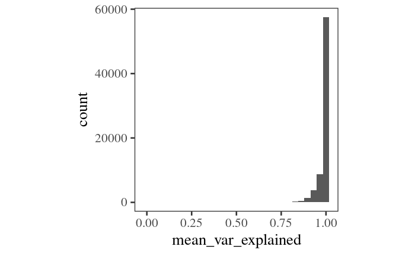

```r
p <- ggplot(proportions_per_rep_single_table, aes(mean_var_explained)) +
  geom_histogram() +
  theme_camprot()

print(p)
```

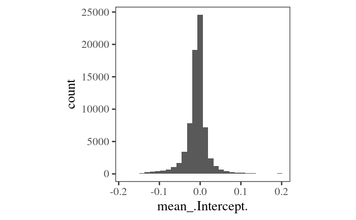

```r
print(p + aes(mean_.Intercept.))
```

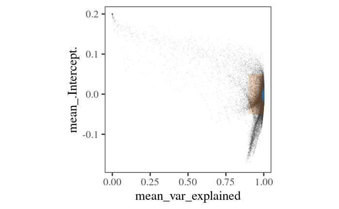

```r
p <- ggplot(proportions_per_rep_single_table, aes(mean_var_explained, mean_.Intercept.)) +
  geom_point(alpha=0.05, size=0.2, colour='grey30') +
  annotate("rect", xmin = .9, xmax = 1, ymin = -0.05, ymax = 0.05,
           alpha = .2, fill=get_cat_palette(2)[2], colour=NA) +
  geom_density2d(colour=get_cat_palette(1)) +
  theme_camprot()


print(p)
```

Set thresholds for variance explained and intercept.

```r
proportions_per_rep_single_table %>%
  mutate(low_var=mean_var_explained<0.9,
         high_intercept=abs(mean_.Intercept.) > 0.05) %>%
  group_by(low_var, high_intercept) %>%
  tally()
```

| low_var | high_intercept | n |
| --- | --- | --- |
| FALSE | FALSE | 65572 |
| FALSE | TRUE | 5109 |
| TRUE | FALSE | 1225 |
| TRUE | TRUE | 1359 |

```r
NA
```

OK, so the about filters will remove ~ 10% of the proportion estimations and seem very reasonable. Let’s see how many genes will remain.

First, if we just filter to retain all genes at least 3/5 quantifications

```r
print(length(unique(proportions_per_rep_single_table$id)))
```

```
[1] 14653
```

```r
proportions_per_rep_single_table %>%
  filter(is.finite(Cytosol)) %>%
  group_by(id) %>%
  summarise(n=length(Cytosol),
            Cytosol=mean(Cytosol)) %>%
  filter(n>=3) %>%
  nrow()
```

```
[1] 14649
```

```r
proportions_per_rep_single_table %>%
  filter(mean_var_explained > 0.9,
         abs(mean_.Intercept.) < 0.05) %>%
  filter(is.finite(Cytosol)) %>%
  group_by(id) %>%
  summarise(n=length(Cytosol),
            Cytosol=mean(Cytosol)) %>%
  filter(n>=3) %>%
  nrow()
```

```
[1] 14066
```

```r
proportions_per_rep_single_table_flt <- proportions_per_rep_single_table %>%
    filter(mean_var_explained > 0.85,
           abs(mean_.Intercept.) < 0.05) %>%
    filter(is.finite(Cytosol)) # can filter on any column here

nrow(proportions_per_rep_single_table)
```

```
[1] 73265
```

```r
nrow(proportions_per_rep_single_table_flt)
```

```
[1] 66279
```

Summarise across replicates

```r
proportions_single_table <- proportions_per_rep_single_table_flt %>%
      group_by(id) %>%
      summarise(n=length(Cytosol),
                sd_Cytosol=sd(Cytosol),
                sd_Nucleus=sd(Nucleus),
                sd_Membrane=sd(Membrane),
                sd_Mitochondrion=sd(Mitochondrion),
                Cytosol=mean(Cytosol),
                Nucleus=mean(Nucleus),
                Membrane=mean(Membrane),
                Mitochondrion=mean(Mitochondrion),) %>%
      filter(n>=3) %>%
      dplyr::select(-n)
```

```r
proportions_per_rep_single_table %>%
  saveRDS('./out/proportions_per_rep_single_table.rds')

proportions_per_rep_single_table_flt %>%
  saveRDS('./out/proportions_per_rep_single_table_flt.rds')

proportions_single_table %>%
  saveRDS('./out/proportions_single_table.rds')
```